# **Jill Ellis’ Journey with the USWNT**

Data Viz Module Project

Lily England

2024-04-22

Imagine yourself in the electrifying atmosphere of a packed stadium, where the cheers of fans echo as the clock ticks down into the final minute of the Women’s World Cup. In this moment, one figure stands out in all the activity. Jill Ellis, the head coach whose impact on the US Women’s National Team (USWNT) extends far beyond the field. Embracing her coaching legacy and building on it is crucial to sustaining the USWNT’s winning tradition and fostering the growth of women’s soccer worldwide.

### **Ellis’ Impressive Record**

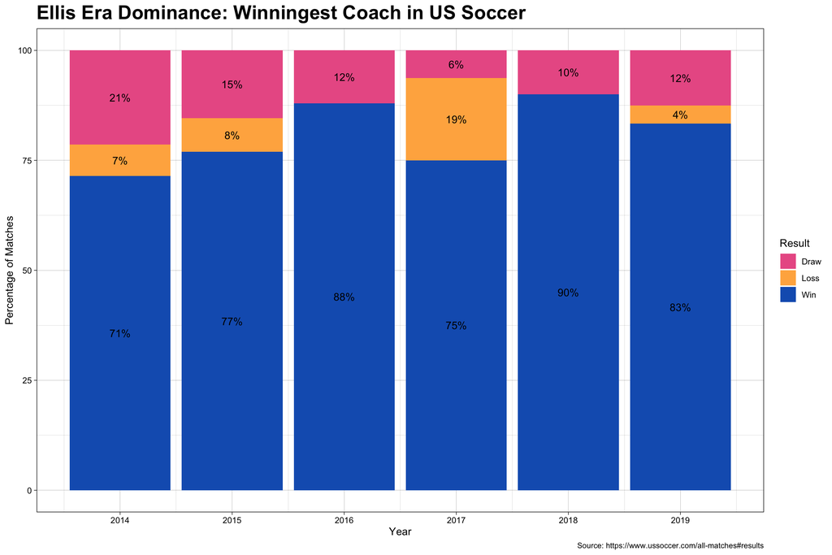

```r
# make stacked bar chart
ggplot(match_percentage, aes(x = Year, y = percentage, fill = result)) +
  geom_bar(stat = "identity") +
  geom_text(data = subset(match_percentage, percentage != 0),
            aes(label = paste0(round(percentage), "%")), #labeling percentages on bar
            position = position_stack(vjust = 0.5))+
  labs(title = "Ellis Era Dominance: Winningest Coach in US Soccer",
       x = "Year",
       y = "Percentage of Matches",
       fill = "Result",
       caption = "Source: https://www.ussoccer.com/all-matches#results") +
  scale_x_continuous(breaks = seq(min(match_percentage$Year), max(match_percentage$Year), by = 1)) + #labeling each year on x-axis
  theme_linedraw() +
  theme(plot.title = element_text(size = 20, face = "bold"),
        plot.caption = element_text(size = 8)) +
  scale_fill_manual(values = c("#EA5F94","#FFB14E","#1560BD"), #adding color palette
                    labels = c("Draw", "Loss", "Win"))
```

This is a simple yet powerful visualization of Ellis’ legacy. It is a stacked bar graph highlighting the team’s performance under her management. Each bar shows the ups and downs of a team always aiming for the top. From the beginning of Ellis’ tenure in 2014, the graph reveals a solid foundation of victories, symbolizing the promising outlook of the team’s performance under their new coach. With only five months to prepare for the 2015 Women’s World Cup, Ellis faced her greatest challenge yet. But she rose to the occasion, transforming a group of talented individuals into a cohesive and threatening team. She led her team to a World Cup trophy. A historic victory that solidified Ellis’ legacy as one of the greatest coaches in USWNT history.

But Ellis’ impact extends far beyond the numbers. In 2017, as the team faced adversity and setbacks coming off of their heartbreaking Olympic loss, what set her apart as a coach was her commitment to player development. This kept the team focused and motivated as they fought through adversity. Through her guidance, players like Alex Morgan and Carli Lloyd emerged stronger and more resilient than ever before, showcasing their skills on the world stage as they prepared for the upcoming World Cup.

Ellis continued to prioritize player development in preparation for the next World Cup. Then in 2019, redemption came in the form of another historic triumph. With Jill Ellis as head coach, the USWNT conquered the world stage, clinching their second consecutive World Cup title and making history once again.

Jill Ellis’ coaching journey, as depicted by this graph, is a testament to her extraordinary leadership. Concluding her career as the winningest coach in US Soccer history, her remarkable record demands respect and admiration. As future coaches analyze her tactics and strategies, they can gain invaluable insights to shape their own approaches, ensuring that Ellis’ legacy continues to shape the future of the sport.

### **Player Development**

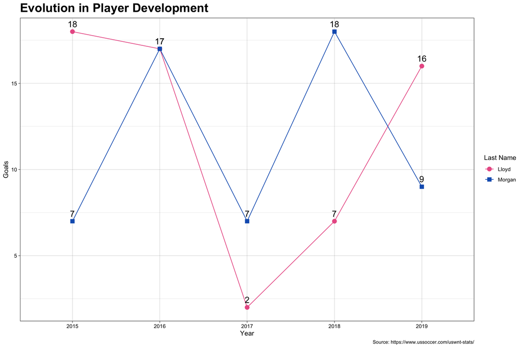

[figure not shown]

Alex Morgan

[figure not shown]

Carli Lloyd

```r
# make line graph for lloyd and morgan goals
ggplot(lloyd_morgan, aes(x = Year,
                         y = G,
                         color = Last,
                         group = Last,
                         label = G)) +
  geom_line(data = subset(lloyd_morgan, Last == "Lloyd"), aes(shape = Last)) +  # Line for Lloyd
  geom_line(data = subset(lloyd_morgan, Last == "Morgan"), aes(shape = Last)) +  # Line for Morgan
  geom_point(data = subset(lloyd_morgan, Last == "Lloyd"), shape = 19, size = 3) +  # Circles for Lloyd
  geom_point(data = subset(lloyd_morgan, Last == "Morgan"), shape = 15, size = 3) + # square for Morgan
  geom_text(color = "black", vjust = -.75, hjust = 0.5, size = 5) + # labels for each point
  scale_color_manual(values = c("#EA5F94","#1560BD")) +
  labs(title = "Evolution in Player Development ",
       x = "Year",
       y = "Goals",
       caption = "Source: https://www.ussoccer.com/uswnt-stats/",
       color = "Last Name") +
  theme_linedraw() +
  theme(plot.title = element_text(size = 20, face = "bold"),
        plot.caption = element_text(size = 8)) #making caption smaller
```

As mentioned earlier in the report, Jill Ellis focused on player development in order to grow her impressive team. Before hiring Jill Ellis as head coach, the USWNT was facing stagnation in player growth. The previous manager was criticized for lacking direction, vision, and a learning environment. Stepping into her role, Jill Ellis was committed to nurturing and developing her players.

> “I know what they want: They want to improve. Alex [Morgan] wants to be the best player in the world. She knows she has to improve. Every single one of these players wants to get better. Going in, I knew that wouldn’t insult them.”- Jill Ellis, 2015

The journeys of Alex Morgan and Carli Lloyd, two of the biggest names in women’s soccer, highlight the way Ellis developed players based on their needs and skillset in order to maximize the team’s overall performance.

In 2015, Alex Morgan faced a pivotal moment in her career. Despite her natural talent, she struggled to consistently find the back of the net. Recognizing her potential, Coach Ellis focused on refining Morgan’s technique and positioning to transform her into a more consistent finisher. Meanwhile, Carli Lloyd was at the peak of her career. She played a major role in the team’s 2015 World Cup success. However, Ellis believed there was still room for improvement. She worked with Lloyd to enhance her tactical awareness and decision making to make her an even bigger threat to opponents.

Throughout their development under Coach Ellis, both Morgan and Lloyd showed significant growth, resulting in a surge in goal production in 2016 where they both scored 17 goals. However, 2017 brought a season of adversity. Ellis provided support and encouragement to Alex Morgan, as she battled with a lack of confidence. During this time, Coach Ellis was also transitioning Carli Lloyd to a new role as a dynamic player coming off the bench. Despite both players facing challenges, Ellis remained confident in their abilities. She believed they would be pivotal parts of the team’s success.

As Ellis continued to develop Morgan and Lloyd, they gained confidence and once again became top scorers. Inspired by Ellis’ guidance, Morgan played with a renewed sense of freedom and confidence, trusting her instincts on the field. This led her to a career high of 18 goals during the season. Similarly, with Coach Ellis’ mentorship, Lloyd embraced her new role as a late-game impact player, learning how to best prepare for her new responsibilities.

And in 2019, their hard work and dedication paid off as Morgan and Lloyd helped their team bring home the World Cup trophy. Their success was not just a testament to their individual talent, but also to the transformative power of player development under Jill Ellis.

Reflecting on the journeys of Alex Morgan and Carli Lloyd, we see the crucial role that player development had in unlocking the full potential of her athletes. Under Jill Ellis’ guidance, Morgan and Lloyd evolved from promising talents into playmakers and leaders.

### **Strategic Player Management**

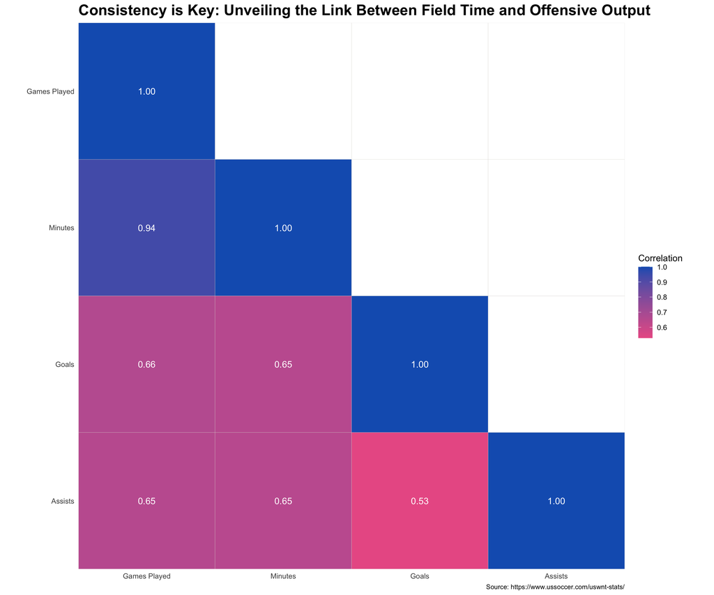

```r
# Make color palette
colorpalette <- c("#EA5F94","#1560BD")

# Create the heatmap with labels
ggplot(corrmatrix, aes(rowname, fct_rev(colname), fill = corr)) +
  geom_tile(color = "#DBD7D2") +  # tile borders set to grey
  geom_text(aes(label = label), color = "white") + #labeling each tile with correlation
  coord_fixed(expand = FALSE) + #fixed aspect ratio
  scale_fill_gradientn(colors = colorpalette,
                       na.value = "white",
                       name = "Correlation") + #sets up color palette gradient
  labs(x = NULL,
       y = NULL,
       title = "Consistency is Key: Unveiling the Link Between Field Time and Offensive Output",
       caption = "Source: https://www.ussoccer.com/uswnt-stats/" ) +
  theme(panel.border = element_rect(color = NA, fill = NA))+ #removing borders
  scale_x_discrete(labels = c("GP" = "Games Played", "Min" = "Minutes", "G" = "Goals", "A" = "Assists")) +  # change x-axis labels
  scale_y_discrete(labels = c("GP" = "Games Played", "Min" = "Minutes", "G" = "Goals", "A" = "Assists")) + #change y axis labels
  theme_minimal() +
  theme(plot.caption = element_text(size = 8),
        plot.title = element_text(size = 18, face = "bold"))
```

Jill Ellis’ coaching philosophy was also deeply rooted in maximizing player potential through strategic management of playing time. The correlation heatmap reveals compelling associations between key metrics such as games played, minutes, goals, and assists. This highlights the importance of consistency in achieving success.

Ellis’ understanding of her players strengths and weaknesses allowed her to utilize them strategically on the field, capitalizing on individual talents. By carefully managing playing time and rotations, Ellis ensured that players remained fresh and energized throughout matches. This enabled them to maintain high levels of performance and productivity.

> “I think if you build a team and you want to harness the assets of a team then you have to understand the strengths of those players, to some degree, the weaknesses of those players. And you have to create something that allows that to strengthen and to grow.”- Jill Ellis

The correlation between games played and both goals and assists emphasizes the significance of player availability. Players who consistently took the field not only contributed directly to goal scoring opportunities but also facilitated the success of their teammates through assists.

Carli Lloyd and Alex Morgan exemplify the correlations depicted in the graph. Both players rank among the top 10 in USWNT game appearances throughout history. Their consistent presence on the field correlates with their remarkable goal-scoring and assist-making capabilities. Both Lloyd and Morgan are also ranked among the top 10 in USWNT goals and assists. This further validates the insights drawn from the heatmap.

Jill Ellis’ coaching legacy is characterized by her strategic management of playing time, which directly influenced goals and assists. By comprehending the correlations between performance metrics and understanding the strengths and weaknesses of the players, coaches can identify areas for improvement and optimize their performance on the field.

### **Conclusion**

Coach Ellis retired in 2019 as a two-time World Cup champion and two-time FIFA World Coach of the Year, but the graphs presented above serve as an important reminder of Ellis’ lasting legacy. Her legacy was built on the foundations of honesty, determination, and a belief in the power of player development. In honoring Jill Ellis’ legacy and building upon it, we not only pay tribute to her impressive achievements as a coach, but also pave the way for future generations of players to find the same success. It’s not just about the multitude of victories during the Ellis Era, but the impact of her coaching tactics and lasting legacy. A legacy that will continue to inspire the USWNT and women’s soccer for generations to come.